# Visualizations

```r
# Bonus: Big countries may now obscure small countries!
```

If we set aesthetic attributes outside `aes()`, they take on static values. For example, `alpha` determines the opaqueness of objects:

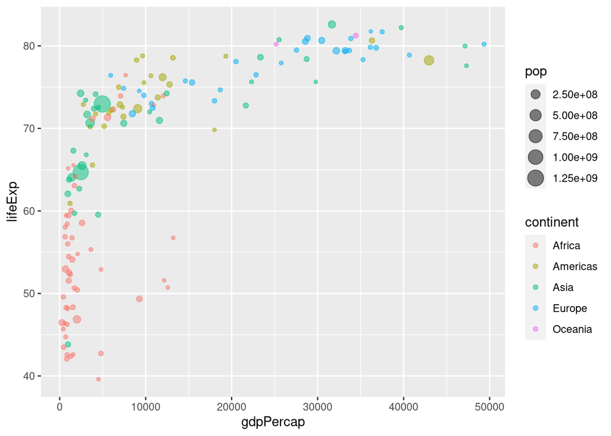

```r
gm |>
  ggplot(aes(x = gdpPercap, y = lifeExp, color = continent, size = pop)) +
  geom_point(alpha = 0.5)
```

You can also set labels for axis & legend using `labs()`:

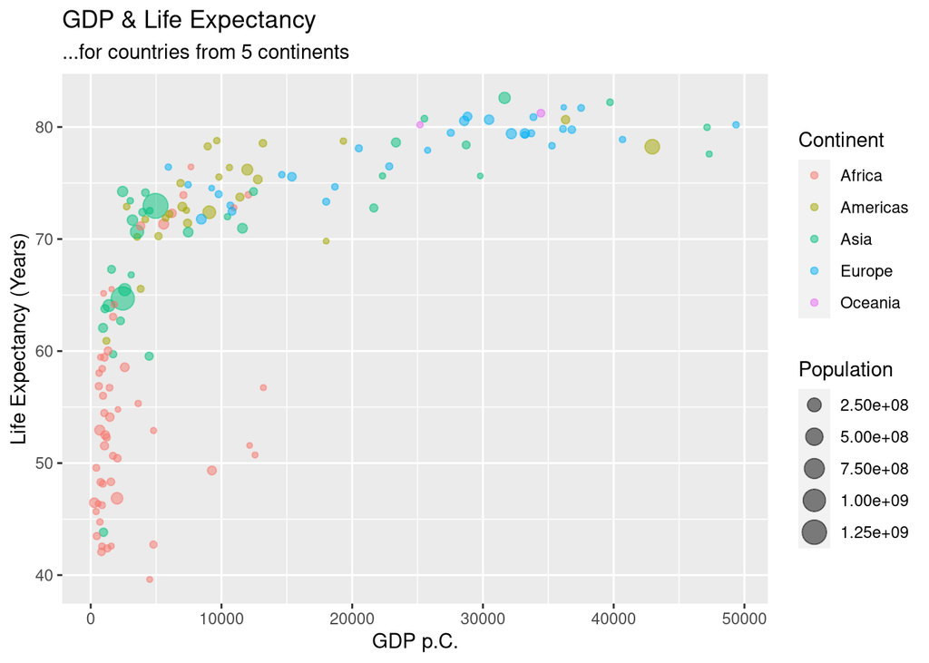

```r
gm |>
  ggplot(aes(x = gdpPercap, y = lifeExp, color = continent, size = pop)) +
  geom_point(alpha = 0.5) +
  labs(
    title = "GDP & Life Expectancy",
    subtitle = "...for countries from 5 continents",
    x = "GDP p.C.",
    y = "Life Expectancy (Years)",
    color = "Continent",
    size = "Population"
  )
```

`ggplot2` also has themes:

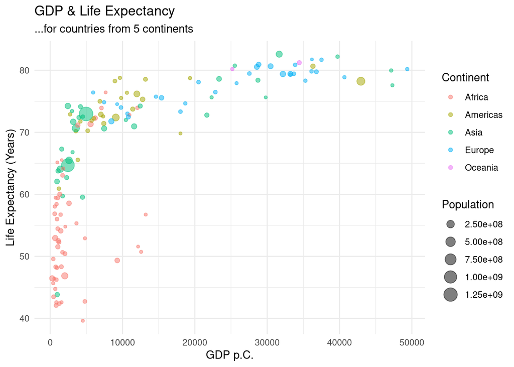

```r
gm |>
  ggplot(aes(x = gdpPercap, y = lifeExp, color = continent, size = pop)) +
  geom_point(alpha = 0.5) +
  labs(
    title = "GDP & Life Expectancy",
    subtitle = "...for countries from 5 continents",
    x = "GDP p.C.",
    y = "Life Expectancy (Years)",
    color = "Continent",
    size = "Population"
  ) +
  theme_minimal()
```

## Other `geom_*`s

Lines (`geom_line()`):

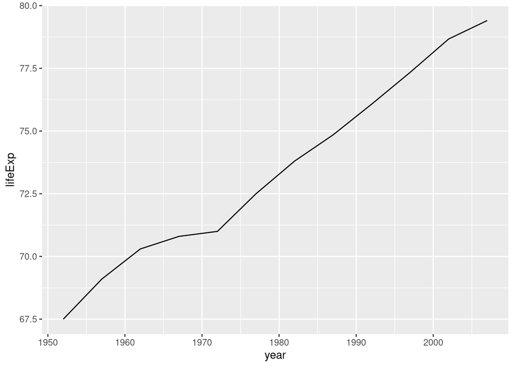

```r
gapminder |>
  filter(country == "Germany") |>
  ggplot(aes(x = year, y = lifeExp)) +
  geom_line()
```

Bars (`geom_bar()` & `geom_col()` (= columns, aka easier to use bars)):

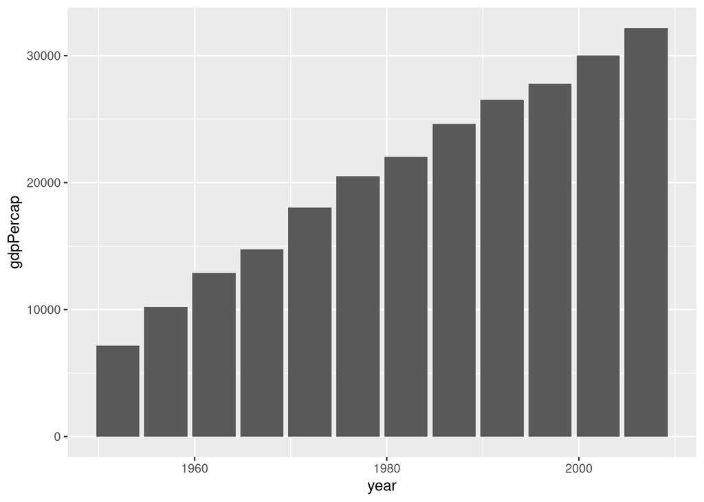

```r
gapminder |>
  filter(country == "Germany") |>
  ggplot(aes(x = year, y = gdpPercap)) +
  geom_col()
```

Violin- & Boxplots (`geom_violin()` & `geom_boxplot()`)

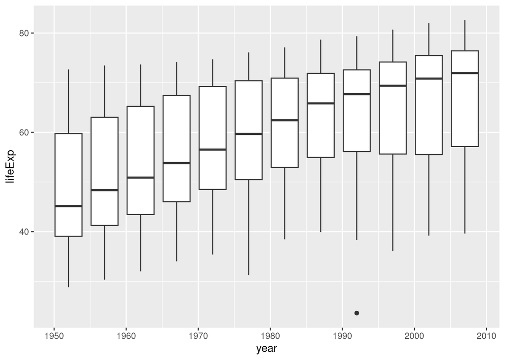

```r
gapminder |>
  ggplot(aes(x = year, y = lifeExp, group = year)) +
  geom_boxplot()
```

## Wraps

Let’s say you wanted to make the last plot *by continent*. Would you have to `filter()` and make plots for all continents separately? There is of course a smarter way: we can “wrap” the plot by continent:

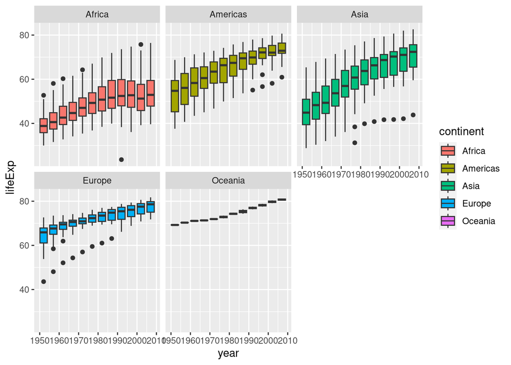

```r
gapminder |>
  ggplot(aes(x = year, y = lifeExp, group = year, fill = continent)) +
  geom_boxplot() +
  facet_wrap(~continent)
```

## Axes, scales & `theme()`-elements

All visual elements of the plot can be changed inside `theme()` (the ggplot2-internal syntax may seem a bit strange at first):

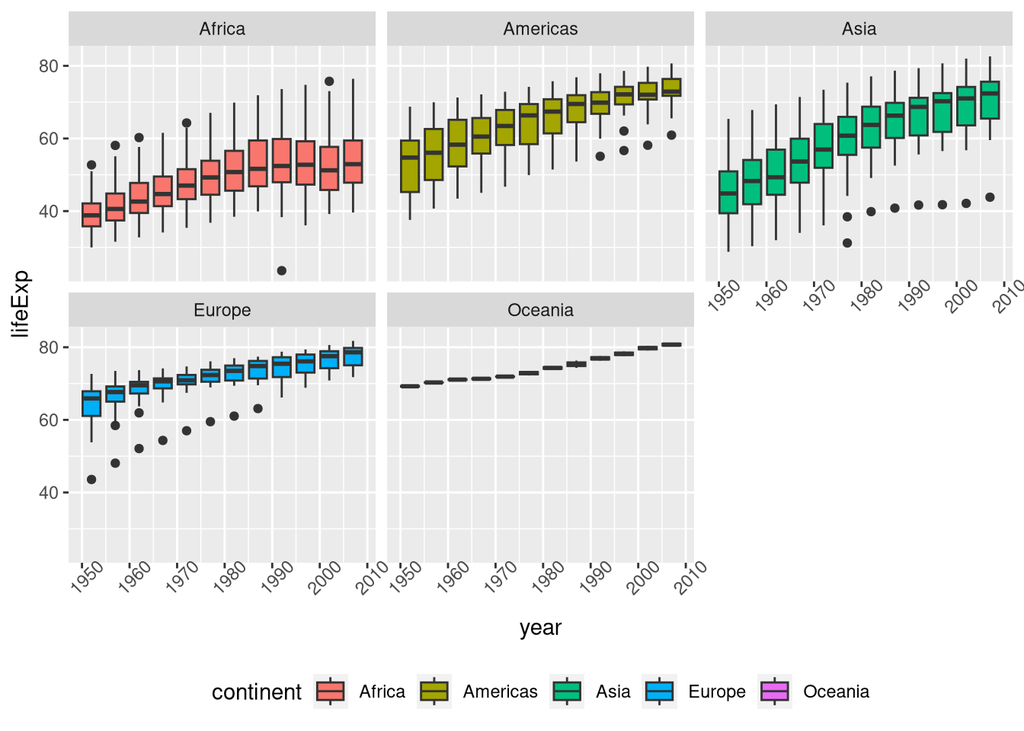

```r
# show "scales::comma_format()" & "scales::percent_format()"
gapminder |>
  ggplot(aes(x = year, y = lifeExp, group = year, fill = continent)) +
  geom_boxplot() +
  facet_wrap(~continent) +
  theme(
    axis.text.x = element_text(angle = 45),
    legend.position = "bottom"
  )
```

Using the `scales`-package, we can also nicely format our axis labels (useful especially if you have things like percentages (`scales::label_percent()`) or very large numbers (`scales::label_comma()` or `scales::label_scientific()`)):

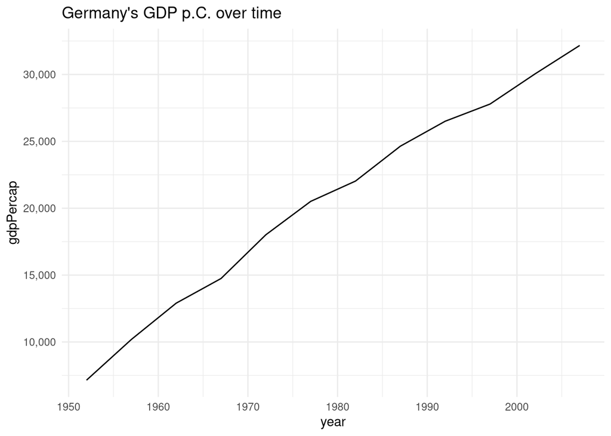

```r
gapminder |>
  filter(country == "Germany") |>
  ggplot(aes(x = year, y = gdpPercap)) +
  geom_line() +
  theme_minimal() +
  labs(title = "Germany's GDP p.C. over time") +
  scale_y_continuous(labels = scales::label_comma())
```

```r
# ^ or even better: scales::label_currency()
```

Inside ggplot2’s `scale_*`-functions, you can also change things like color and fill scales. Recall our original plot:

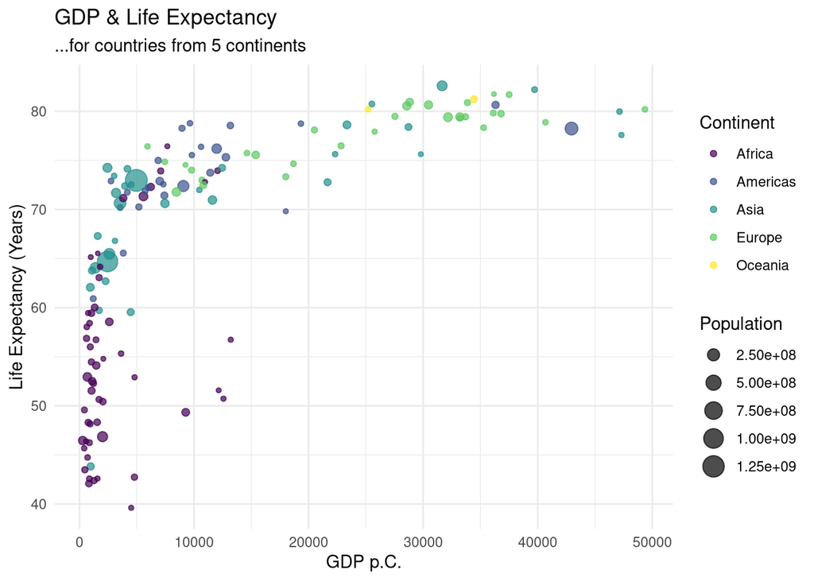

```r
gm |>
  ggplot(aes(x = gdpPercap, y = lifeExp, color = continent, size = pop)) +
  geom_point(alpha = 0.7) +
  labs(
    title = "GDP & Life Expectancy",
    subtitle = "...for countries from 5 continents",
    x = "GDP p.C.",
    y = "Life Expectancy (Years)",
    color = "Continent",
    size = "Population"
  ) +
  theme_minimal() +
  scale_color_viridis_d()
```

```r
  # Or others:
  #scale_color_brewer(palette = "Accent")
```

If you are interested in visualizations, you can read up on color & fill scales and color theory for ggplot2 [here](https://ggplot2-book.org/scales-colour).

### Putting it all together

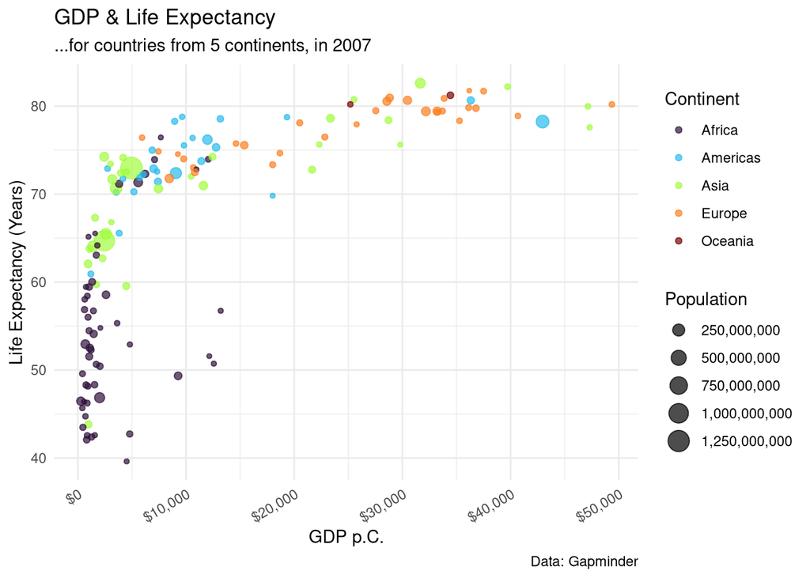

```r
gm |>
  ggplot(aes(x = gdpPercap, y = lifeExp, color = continent, size = pop)) +
  geom_point(alpha = 0.7) +
  labs(
    title = "GDP & Life Expectancy",
    subtitle = "...for countries from 5 continents, in 2007",
    x = "GDP p.C.",
    y = "Life Expectancy (Years)",
    color = "Continent",
    size = "Population",
    caption = "Data: Gapminder"
  ) +
  theme_minimal() +
  theme(axis.text.x = element_text(angle = 30, hjust = 1)) +
  # ^ You can also change horizontal (hjust) and vertical (vjust) alignment!
  scale_color_viridis_d(option = "turbo") +
  scale_x_continuous(labels = scales::label_currency()) +
  scale_size_continuous(labels = scales::comma_format())
```

```r
# Also works for `aes()` other than axes (here: changes the labeling of the "size"
# mapping in the legend).
```

# Bonus: Animations

```r
library(gganimate)
library(transformr)
library(gifski)
```

First we specify our animation. This is just a ggplot with a variable for transitioning (in our case: `year`), and some optional other parameters (like how to handle/ease transitions between frames):

```r
animation <-

  # First the plot:

  gapminder |> # Notice we use gapminder (the data for all years)!
  ggplot(aes(x = gdpPercap, y = lifeExp, color = continent, size = pop)) +
  geom_point(alpha = 0.7) +
  labs(
    title = "GDP & Life Expectancy",
    # We change the subtitle to show the Years during the animation.
    # You can access the current frame (year) with `closest_state`
    subtitle = "Year: { closest_state }",
    x = "GDP p.C.",
    y = "Life Expectancy (Years)",
    color = "Continent",
    size = "Population",
    caption = "Data: Gapminder"
  ) +
  theme_minimal() +
  theme(axis.text.x = element_text(angle = 30, hjust = 1)) +
  scale_x_continuous(labels = scales::label_currency()) +
  scale_size_continuous(labels = scales::comma_format()) +

  # Then what variable to animate/transition on:

  transition_states(states = year, transition_length = 2, state_length = 1) +
  ease_aes('linear') +
  exit_fade()
```

Then we animate it. You can use different backends & formats; here, we want to export to a GIF using `gifski`:

```r
animate(
  animation,
  duration = 8,
  fps = 30,
  width = 700,
  height = 500,
  renderer = gifski_renderer()
)
```

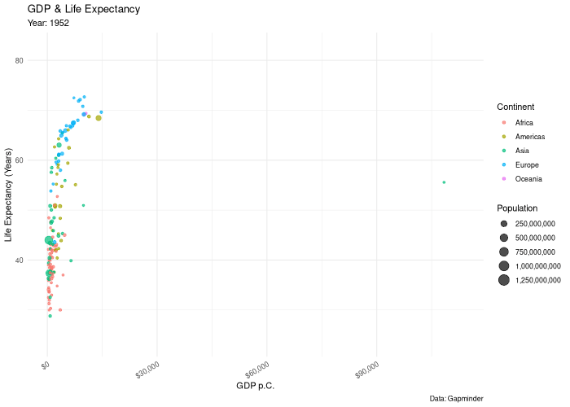

If you want to, you can save it:

```r
anim_save("animation.gif") # saves the last animation by default
```